# Analysis of Inventory Generation Methods for Forest Simulation

# Effects of Diameter Distribution Methods

**Figure 3: Forest dynamics variation due to different diameter distribution initialization methods**

We fix species proportions to “fixe” (deterministic) and examine variation caused by different diameter distribution methods. The analysis covers multiple forest variables to assess the comprehensive impact of initialization choices.

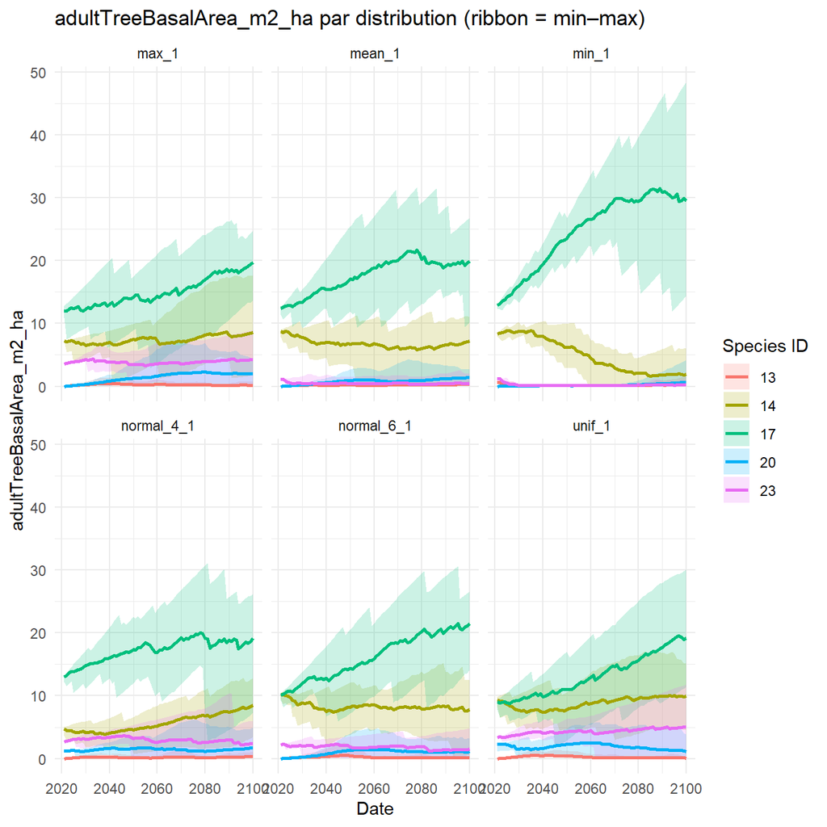

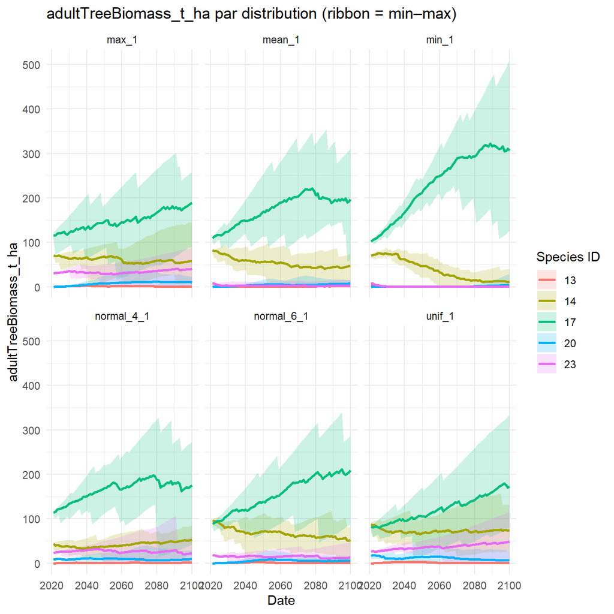

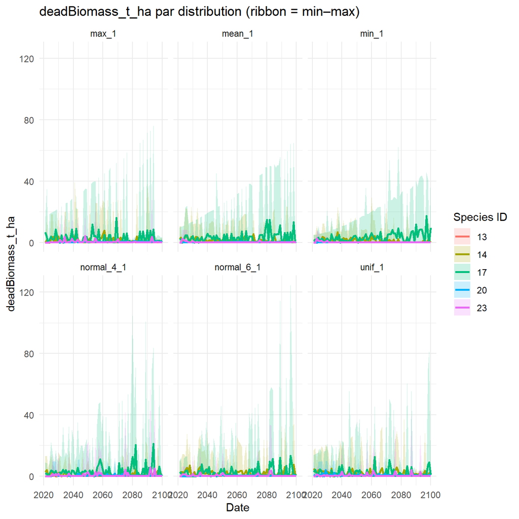

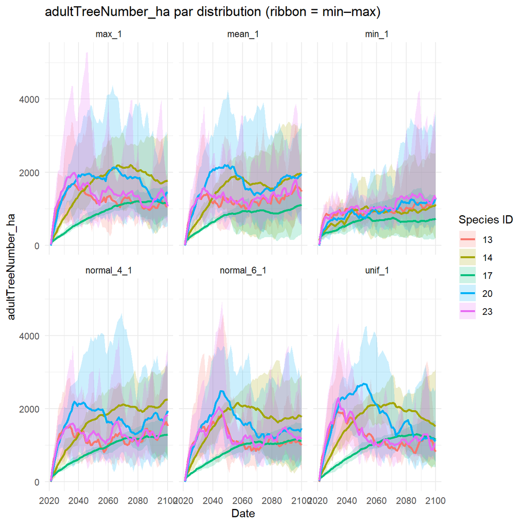

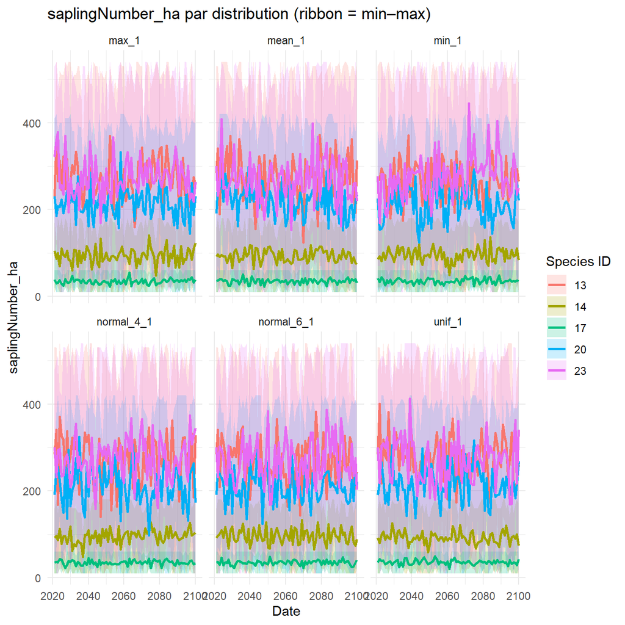

# Effects of Species Proportion Methods

**Figure 4: Forest dynamics variation due to different species proportion initialization methods**

We fix diameter distribution to “mean” and examine variation caused by different species proportion allocation methods (deterministic vs. stochastic).

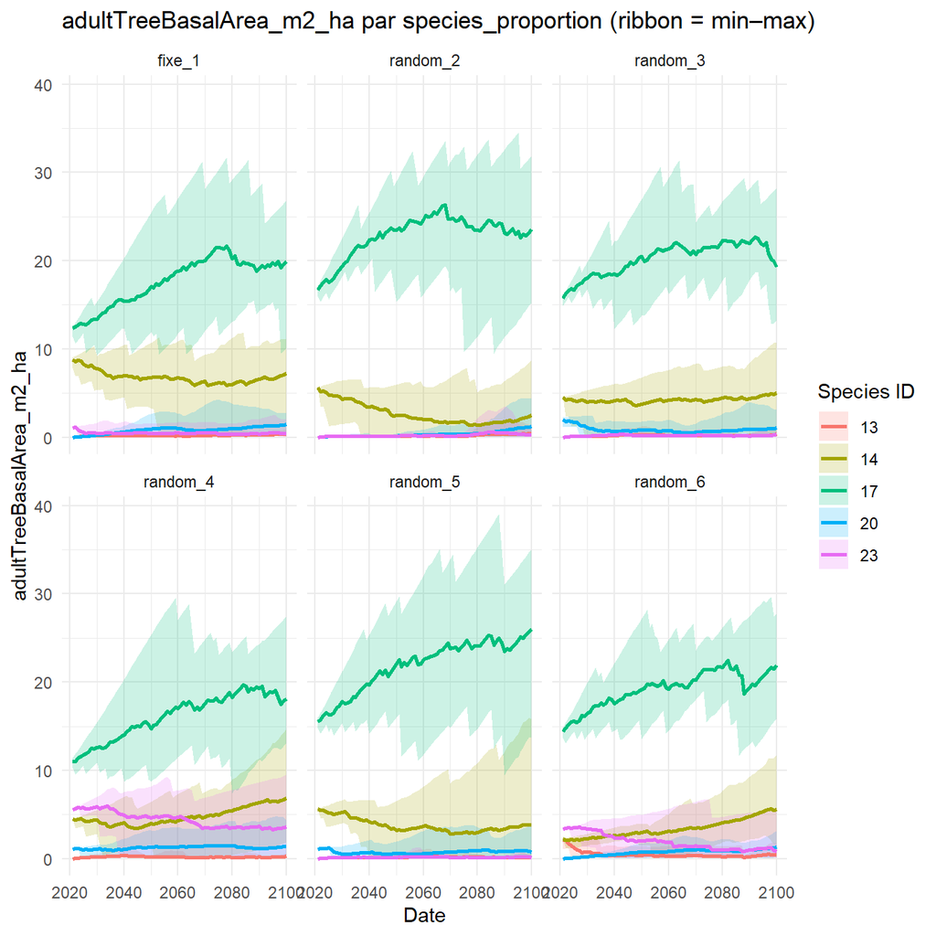

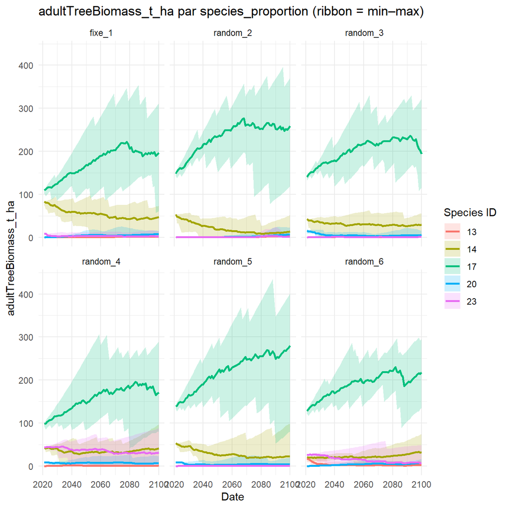

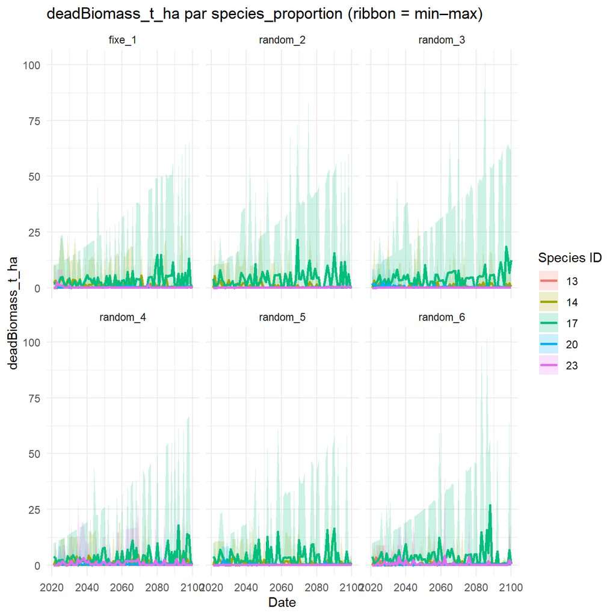

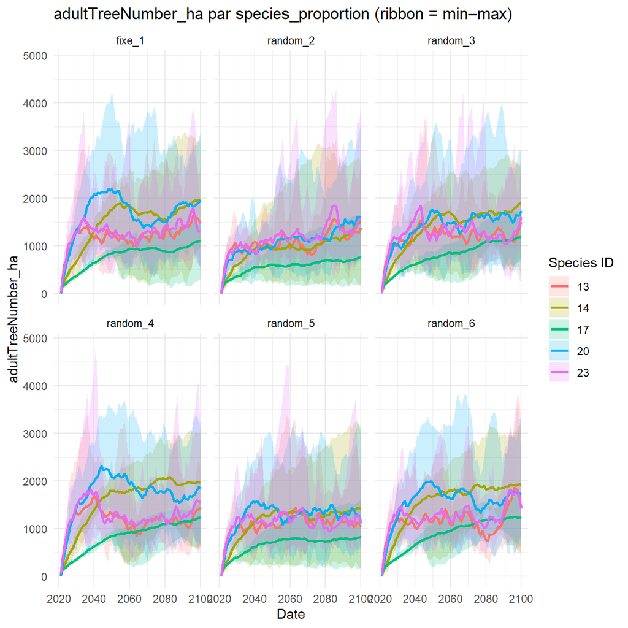

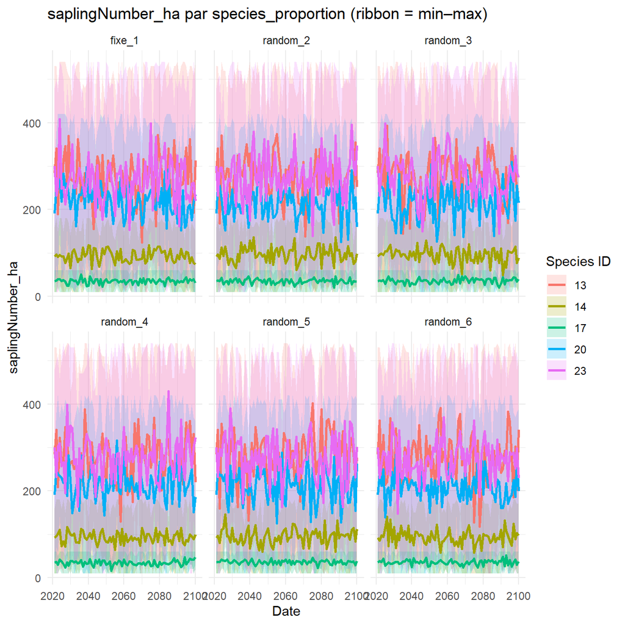

# Discussion and Future Directions

## Key Findings

This preliminary analysis reveals several important patterns in forest simulation initialization:

1. **Substantial stochastic variation**: The FORCEEPS model exhibits considerable internal variation across simulation seeds, emphasizing the need for multiple replications to obtain robust results.
2. **Initialization method effects**: Both diameter distribution and species proportion allocation methods produce detectable differences in forest dynamics, though these effects must be evaluated against the background of stochastic model variation.
3. **Variable sensitivity**: Different forest variables (basal area, biomass, tree numbers) show varying degrees of sensitivity to initialization choices.

## Methodological Implications

The analysis raises critical questions about inventory generation protocols: - How should fractional tree representations be handled in small plots? - What level of variation around initial data is appropriate given measurement uncertainties? - How do initialization effects compare in magnitude to model stochastic variation?

## Future Research Priorities

To advance this work, future analyses should:

1. **Quantify initialization vs. stochastic variation**: Develop statistical methods to compare the magnitude of variation between initialization methods against internal model stochasticity.
2. **Test multiple forest types**: Expand analysis beyond the Retz forest to other forest ecosystems to assess the generalizability of findings.
3. **Develop standardized protocols**: Establish evidence-based guidelines for inventory generation that balance biological realism with computational efficiency.
4. **Long-term dynamics**: Assess whether initialization effects persist, amplify, or diminish over extended simulation periods.

This preliminary investigation provides a foundation for more comprehensive research into the critical but often overlooked question of how initial conditions affect forest simulation outcomes.